# NBA

Antonio Pascual Hernandez

28 de Octubre de 2020

El objetivo de este informe es estudiar el salario de los jugadores de la NBA a traves de las variables del dataset nba y crear un modelo que nos permita predecir el salario y el peso de cada variable en el mismo. En ultimo lugar, se va a realizar una prediccion del salario de 10 jugadores aleatorios de la NBA.

Hemos eliminado los NAs y debemos comprobar que no haya jugadores duplicados en el dataset, ya que los resultados se podrian ver afectados. Existen 2 datos duplicados, por lo que tendremos que eliminarlos.

## Graficos

A continuacion se va a representar graficamente una serie de variables del dataset de la NBA.

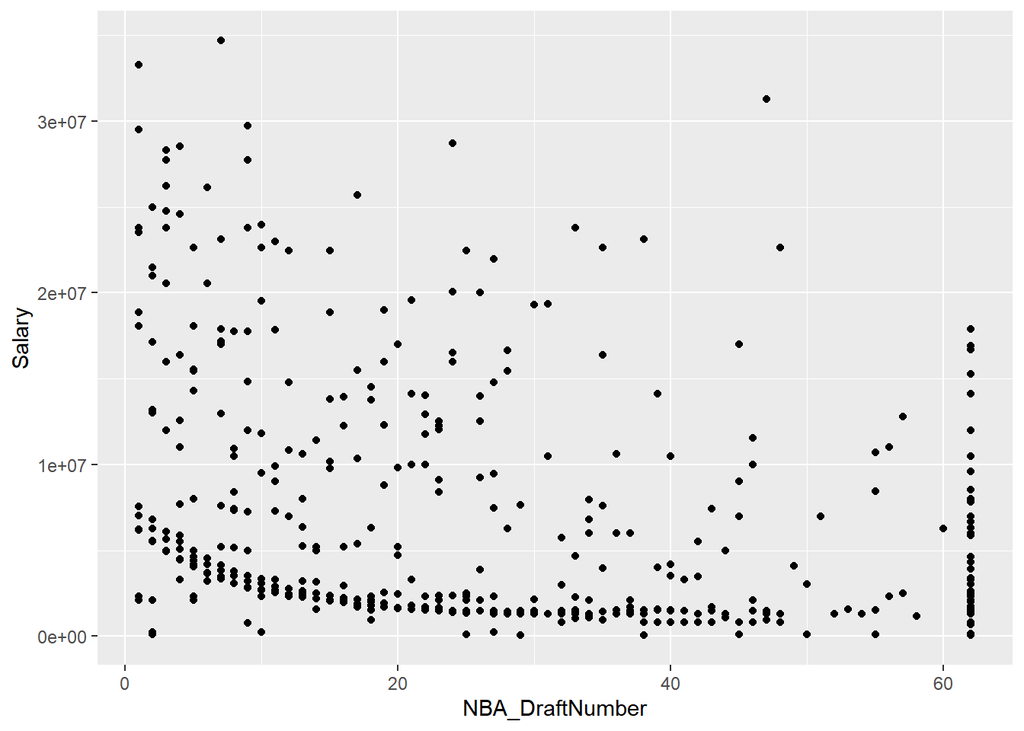

Se puede obdervar que los jugadores que fueron seleccionados antes en el Draft tienden a tener un mayor salario

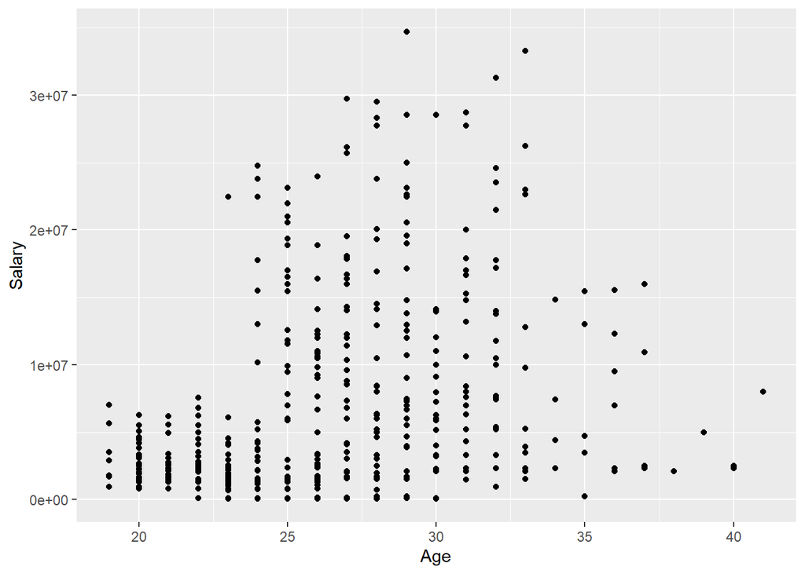

Observamos que los jugadores mas jovenes no obtienen salarios muy altos. Es a partir de los 24-25 anos cuando los salarios comienzan a ser mas elevados. La mayor concentracion de los salarios mas elevados se encuentra entre los 24 y 33 anos. A partir de los 34 anos, los salarios comienzan a ser mas bajos.

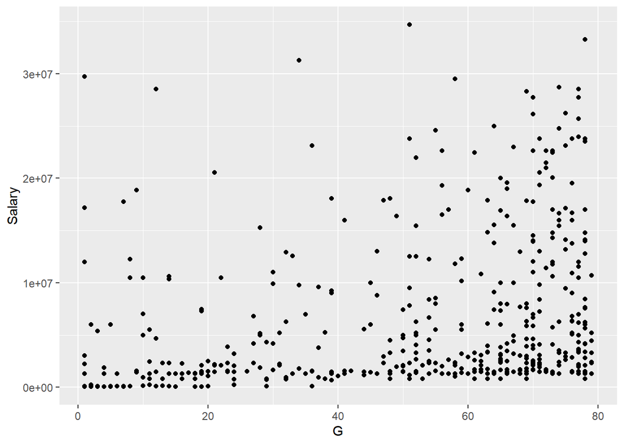

Se puede observar que los jugadores que disputan mas partidos son aquellos con un salario. Sin embargo, observamos que hay jugadores que han disputado pocos partidos durante la temporada pero su salario es muy elevado. Esto se puede deber, por ejemplo, que esos jugadores no han podido disputar muchos partidos debido a lesiones o sanciones.

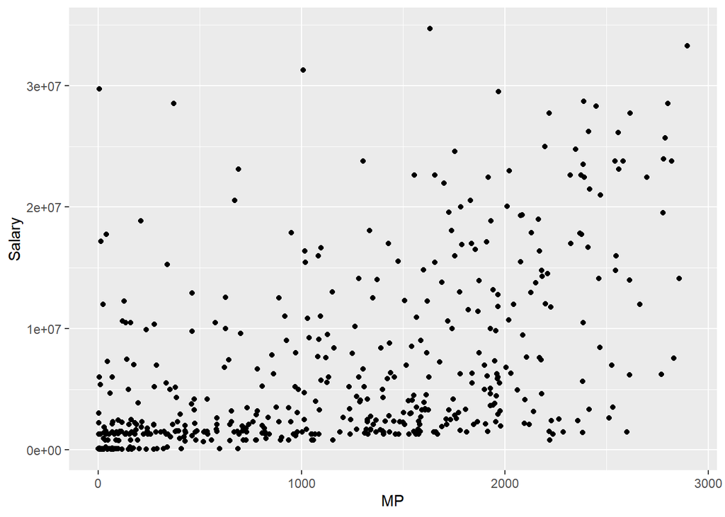

Si se observa el grafico anterior que estudia la relacion entre los munitos jugados y el salario, se puede extraer que los jugadores con mas munitos jugados tienden a ser los que tienen un salario mas elevado. Sin embargo, se encuentran jugadores que han disputado pocos munitos pero su salario es muy elevado.

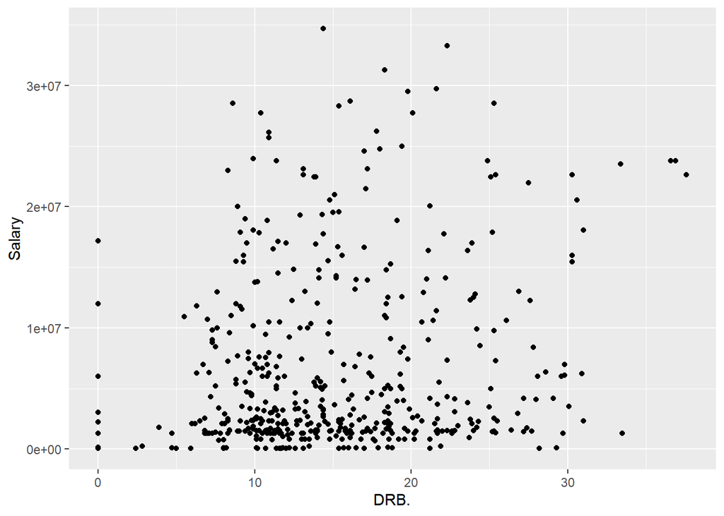

En cuanto al porcentaje de rebotes defensivos y el salario, los jugadores con un mayor salario tienen un porcentaje de rebotes defensivos se encuentra entre 10% y 30%.

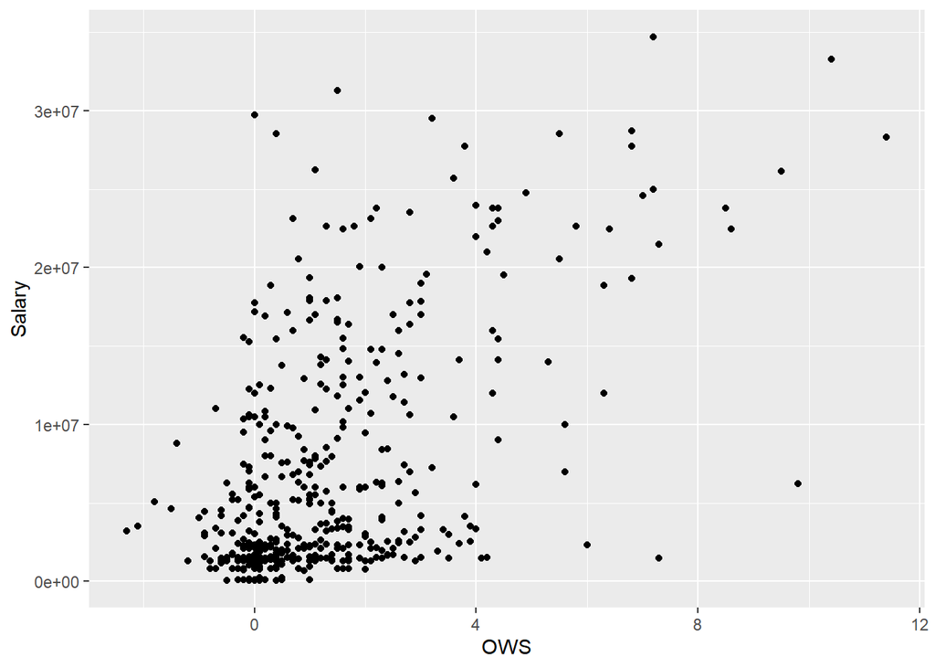

Al estudiar la relación del salario y la apartacion del jugador a las victorias de su equipo, observamos que son los jugadores que mas contribuyen a las vistorias de sus equipos lo que tienen un salario mayor.

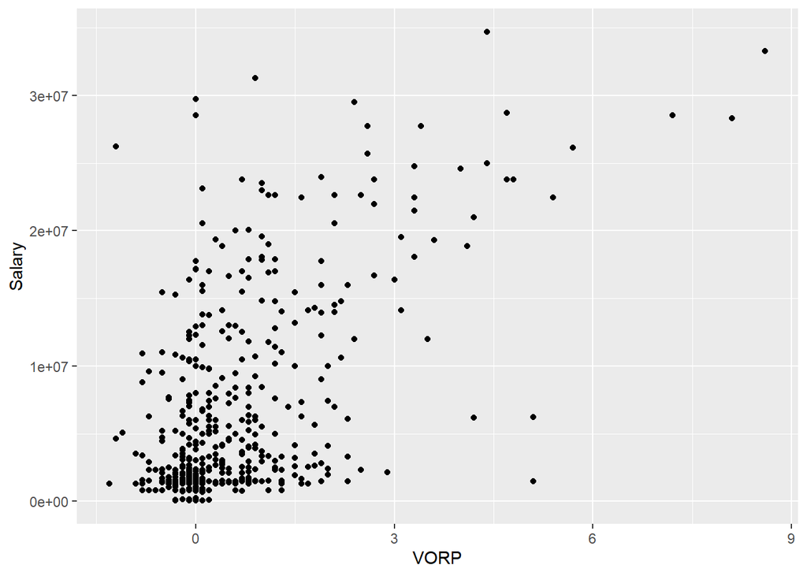

Se observa que al estudiar la relación entre el salario el valor sobre el jugador reemplazado, son quellos jugadores cuyo valor a suparado en gran medida al jugador al que ha reemplazado son los que tienen un mayor salario.

## Modelos

El primero modelo esta compuesto por todas las variables, excepto el pais de procedencia del jugador y su nombre

```
##
## Call:
## lm(formula = Salary ~ . - NBA_Country - Player, data = datos)
##
## Residuals:
##       Min        1Q    Median        3Q       Max
## -14498503  -2888765   -458444   2291882  20324440
##
## Coefficients:
##                 Estimate Std. Error t value Pr(>|t|)
## (Intercept)     -3014178    5974976  -0.504    0.614
## NBA_DraftNumber   -58523      13782  -4.246 2.67e-05 ***
## Age               523548      60370   8.672  < 2e-16 ***
## TmBOS            -226264    2172576  -0.104    0.917
## TmBRK             150499    2012351   0.075    0.940
## TmCHI           -1111092    1999593  -0.556    0.579
## TmCHO            1706729    1988558   0.858    0.391
## TmCLE            1371988    2192053   0.626    0.532
## TmDAL           -1048104    1911597  -0.548    0.584
## TmDEN            -932981    2018324  -0.462    0.644
## TmDET             543366    2039128   0.266    0.790
## TmGSW           -1155719    2250042  -0.514    0.608
## TmHOU           -2619580    2152762  -1.217    0.224
## TmIND           -1254149    1933956  -0.648    0.517
## TmLAC            -471968    2042725  -0.231    0.817
## TmLAL           -1311087    1935762  -0.677    0.499
## TmMEM             745313    1919756   0.388    0.698
## TmMIA           -1034150    1985599  -0.521    0.603
## TmMIL            -615601    1984520  -0.310    0.757
## TmMIN            -659045    2162936  -0.305    0.761
## TmNOP           -2255012    2032302  -1.110    0.268
## TmNYK            -315430    1980360  -0.159    0.874
## TmOKC            2214755    2075867   1.067    0.287
## TmORL             538461    1904320   0.283    0.777
## TmPHI           -1842010    2074225  -0.888    0.375
## TmPHO            -747324    1994256  -0.375    0.708
## TmPOR             514615    2020523   0.255    0.799
## TmSAC            -373969    2216251  -0.169    0.866
## TmSAS             187457    2056201   0.091    0.927
## TmTOR            1092707    2089926   0.523    0.601
```

[output cut: 16 more lines]

```
## USG.              197645     126745   1.559    0.120
## OWS               163577    4749618   0.034    0.973
## DWS              -390727    4767170  -0.082    0.935
## WS                402261    4757373   0.085    0.933
## WS.48            9098649   15076604   0.603    0.546
## OBPM             3415849    5010754   0.682    0.496
## DBPM             3159369    4895414   0.645    0.519
## BPM             -2971467    4916750  -0.604    0.546
## VORP              540503     658093   0.821    0.412
## ---
## Signif. codes:  0 '***' 0.001 '**' 0.01 '*' 0.05 '.' 0.1 ' ' 1
##
## Residual standard error: 5174000 on 428 degrees of freedom
## Multiple R-squared:  0.5658, Adjusted R-squared:  0.511
## F-statistic: 10.33 on 54 and 428 DF,  p-value: < 2.2e-16
```

```
##     (Intercept) NBA_DraftNumber             Age           TmBOS           TmBRK
##   -3014178.4877     -58523.1808     523547.5256    -226263.9125     150498.7541
##           TmCHI           TmCHO           TmCLE           TmDAL           TmDEN
##   -1111091.8798    1706728.7947    1371987.7245   -1048103.5017    -932981.4776
##           TmDET           TmGSW           TmHOU           TmIND           TmLAC
##     543366.1821   -1155718.6515   -2619580.1658   -1254149.4517    -471968.3712
##           TmLAL           TmMEM           TmMIA           TmMIL           TmMIN
##   -1311086.6495     745312.8422   -1034150.0550    -615601.2690    -659044.7185
##           TmNOP           TmNYK           TmOKC           TmORL           TmPHI
##   -2255011.7337    -315429.8928    2214755.0480     538461.4493   -1842010.1848
##           TmPHO           TmPOR           TmSAC           TmSAS           TmTOR
##    -747324.2422     514614.5271    -373969.2425     187457.0697    1092706.7994
##           TmTOT           TmUTA           TmWAS               G              MP
##    -409471.8840   -1824101.1505    1150339.1679    -177943.9515       6440.3020
##             PER             TS.           X3PAr             FTr            ORB.
##    -431679.3179    -743319.4574   -3032084.3262    -270746.6765   -2033872.3031
##            DRB.            TRB.            AST.            STL.            BLK.
##   -1866928.1361    4025557.9356        -54.9963    -158144.7333      97762.0799
##            TOV.            USG.             OWS             DWS              WS
##     -11232.5403     197645.1523     163576.5279    -390726.7255     402261.0298
##           WS.48            OBPM            DBPM             BPM            VORP
##    9098648.7948    3415848.7947    3159369.0825   -2971467.2529     540503.3046
```

El segundo modelo está compuesto por todas las variables del dataset, excepto el nombre del jugador

```
##
## Call:
## lm(formula = Salary ~ . - Player, data = datos)
##
## Residuals:
##       Min        1Q    Median        3Q       Max
## -13909641  -2688087    -76028   2249552  20932066
##
## Coefficients:
##                              Estimate Std. Error t value Pr(>|t|)
## (Intercept)                 -12062057    7375756  -1.635 0.102790
## NBA_CountryAustralia          5473037    4453851   1.229 0.219885
## NBA_CountryAustria            1798244    6896545   0.261 0.794428
## NBA_CountryBahamas            1949514    6791044   0.287 0.774212
## NBA_CountryBosnia             8972886    6750363   1.329 0.184554
## NBA_CountryBosnia & Herz...  -4161409    6797175  -0.612 0.540750
## NBA_CountryBrazil             5294275    4721722   1.121 0.262876
## NBA_CountryCameroon          -1951149    5105640  -0.382 0.702557
## NBA_CountryCanada             4707704    4358066   1.080 0.280717
## NBA_CountryChina              5769941    6896026   0.837 0.403277
## NBA_CountryCroatia            4205678    4611771   0.912 0.362369
## NBA_CountryCzech Republic      445856    6754827   0.066 0.947408
## NBA_CountryDemocratic Re...  12761147    5517459   2.313 0.021256 *
## NBA_CountryDemocratic Re_    11261425    6769380   1.664 0.097010 .
## NBA_CountryDominican Rep...  10277768    5726386   1.795 0.073468 .
## NBA_CountryEgypt              8363757    6719515   1.245 0.214000
## NBA_CountryFinland            2780800    6777723   0.410 0.681825
## NBA_CountryFrance            10697261    4356134   2.456 0.014503 *
## NBA_CountryGeorgia            -768248    6711180  -0.114 0.908923
## NBA_CountryGermany            4441648    4680150   0.949 0.343196
## NBA_CountryGreece             4945478    5692836   0.869 0.385542
## NBA_CountryHaiti              4159615    6783209   0.613 0.540091
## NBA_CountryIsrael            -3246383    6763330  -0.480 0.631502
## NBA_CountryItaly              7904807    5491605   1.439 0.150840
## NBA_CountryLatvia             2287551    5469548   0.418 0.676009
## NBA_CountryLithuania          2566471    5259451   0.488 0.625847
## NBA_CountryMali               5169384    6767755   0.764 0.445439
## NBA_CountryMontenegro         5787771    5475448   1.057 0.291156
## NBA_CountryNew Zealand       10536076    6888758   1.529 0.126972
## NBA_CountryPoland             4288081    6701054   0.640 0.522611
```

[output cut: 59 more lines]

```
## USG.                           254705     137293   1.855 0.064333 .
## OWS                            541102    4958320   0.109 0.913156
## DWS                            366658    4966003   0.074 0.941181
## WS                              74783    4974774   0.015 0.988014
## WS.48                        16202283   16145105   1.004 0.316230
## OBPM                          5008462    5132167   0.976 0.329729
## DBPM                          5331464    5030176   1.060 0.289856
## BPM                          -4973292    5039445  -0.987 0.324325
## VORP                           388696     673130   0.577 0.563976
## ---
## Signif. codes:  0 '***' 0.001 '**' 0.01 '*' 0.05 '.' 0.1 ' ' 1
##
## Residual standard error: 5113000 on 385 degrees of freedom
## Multiple R-squared:  0.6184, Adjusted R-squared:  0.5223
## F-statistic: 6.433 on 97 and 385 DF,  p-value: < 2.2e-16
```

```
##                 (Intercept)        NBA_CountryAustralia
##               -12062056.875                 5473036.995
##          NBA_CountryAustria          NBA_CountryBahamas
##                 1798243.793                 1949514.007
##           NBA_CountryBosnia NBA_CountryBosnia & Herz...
##                 8972885.899                -4161408.845
##           NBA_CountryBrazil         NBA_CountryCameroon
##                 5294274.470                -1951148.495
##           NBA_CountryCanada            NBA_CountryChina
##                 4707703.964                 5769940.738
##          NBA_CountryCroatia   NBA_CountryCzech Republic
##                 4205678.161                  445856.186
## NBA_CountryDemocratic Re...   NBA_CountryDemocratic Re_
##                12761147.201                11261424.833
## NBA_CountryDominican Rep...            NBA_CountryEgypt
##                10277768.059                 8363757.230
##          NBA_CountryFinland           NBA_CountryFrance
##                 2780799.979                10697260.680
##          NBA_CountryGeorgia          NBA_CountryGermany
##                 -768248.394                 4441647.980
##           NBA_CountryGreece            NBA_CountryHaiti
##                 4945477.915                 4159615.051
##           NBA_CountryIsrael            NBA_CountryItaly
##                -3246382.538                 7904807.441
##           NBA_CountryLatvia        NBA_CountryLithuania
##                 2287551.368                 2566470.560
##             NBA_CountryMali       NBA_CountryMontenegro
##                 5169384.189                 5787770.770
##      NBA_CountryNew Zealand           NBA_CountryPoland
##                10536075.551                 4288080.770
##      NBA_CountryPuerto Rico           NBA_CountryRussia
##                 1893980.464                17149316.134
##          NBA_CountrySenegal           NBA_CountrySerbia
##                14992665.823                 2507499.468
##         NBA_CountrySlovenia      NBA_CountrySouth Sudan
##                 8791844.124                 8226636.113
##            NBA_CountrySpain           NBA_CountrySweden
##                 5838897.612                 4999488.971
##      NBA_CountrySwitzerland          NBA_CountryTunisia
##                -2543945.474                 2782631.459
```

[output cut: 43 more lines]

```
##                -2450822.670                -2343850.293
##                        TRB.                        AST.
##                 4930230.977                   36472.489
##                        STL.                        BLK.
##                 -227903.842                  -73697.308
##                        TOV.                        USG.
##                  -90094.421                  254704.579
##                         OWS                         DWS
##                  541102.033                  366657.894
##                          WS                       WS.48
##                   74783.285                16202283.054
##                        OBPM                        DBPM
##                 5008461.874                 5331464.125
##                         BPM                        VORP
##                -4973291.788                  388695.800
```

El tercer modelo está compuesto por las variables Número del Draft(NBA_DraftNumber), Edad (Age), Partidos(G) y Minutos Jugados(MP)

```
##
## Call:
## lm(formula = Salary ~ NBA_DraftNumber + Age + G + MP, data = datos)
##
## Residuals:
##       Min        1Q    Median        3Q       Max
## -11612391  -3346024   -515519   2253672  21872778
##
## Coefficients:
##                   Estimate Std. Error t value Pr(>|t|)
## (Intercept)     -5925029.7  1637283.5  -3.619 0.000327 ***
## NBA_DraftNumber   -78950.4    12426.4  -6.353 4.91e-10 ***
## Age               541868.6    57205.3   9.472  < 2e-16 ***
## G                -182240.1    20185.5  -9.028  < 2e-16 ***
## MP                  8498.7      631.9  13.450  < 2e-16 ***
## ---
## Signif. codes:  0 '***' 0.001 '**' 0.01 '*' 0.05 '.' 0.1 ' ' 1
##
## Residual standard error: 5349000 on 478 degrees of freedom
## Multiple R-squared:  0.4817, Adjusted R-squared:  0.4773
## F-statistic: 111.1 on 4 and 478 DF,  p-value: < 2.2e-16
```

```
##     (Intercept) NBA_DraftNumber             Age               G              MP
##    -5925029.715      -78950.443      541868.580     -182240.052        8498.729
```

## Comparación de modelos.

```
## Analysis of Variance Table
##
## Model 1: Salary ~ NBA_DraftNumber + Age + G + MP
## Model 2: Salary ~ (Player + NBA_Country + NBA_DraftNumber + Age + Tm +
##     G + MP + PER + TS. + X3PAr + FTr + ORB. + DRB. + TRB. + AST. +
##     STL. + BLK. + TOV. + USG. + OWS + DWS + WS + WS.48 + OBPM +
##     DBPM + BPM + VORP) - Player
## Model 3: Salary ~ (Player + NBA_Country + NBA_DraftNumber + Age + Tm +
##     G + MP + PER + TS. + X3PAr + FTr + ORB. + DRB. + TRB. + AST. +
##     STL. + BLK. + TOV. + USG. + OWS + DWS + WS + WS.48 + OBPM +
##     DBPM + BPM + VORP) - NBA_Country - Player
##   Res.Df        RSS  Df   Sum of Sq      F   Pr(>F)
## 1    478 1.3674e+16
## 2    385 1.0067e+16  93  3.6073e+15 1.4835 0.005563 **
## 3    428 1.1456e+16 -43 -1.3888e+15 1.2352 0.155280
## ---
## Signif. codes:  0 '***' 0.001 '**' 0.01 '*' 0.05 '.' 0.1 ' ' 1
```

```
##            df      AIC
## regresion3  6 16343.26
## regresion2 99 16381.34
## regresion1 56 16357.76
```

```
##            df      BIC
## regresion3  6 16368.34
## regresion2 99 16795.16
## regresion1 56 16591.84
```

Se selecciona el modelo con menor AIC, por lo que seleccionaremos el tercer modelo.

## BEST SUBSET

Consiste en estimar todas las regresiones posibles con las combinaciones de los p regresores.

```
## Subset selection object
## Call: regsubsets.formula(Salary ~ . - Player - Tm - NBA_Country, datos)
## 24 Variables  (and intercept)
##                 Forced in Forced out
## NBA_DraftNumber     FALSE      FALSE
## Age                 FALSE      FALSE
## G                   FALSE      FALSE
## MP                  FALSE      FALSE
## PER                 FALSE      FALSE
## TS.                 FALSE      FALSE
## X3PAr               FALSE      FALSE
## FTr                 FALSE      FALSE
## ORB.                FALSE      FALSE
## DRB.                FALSE      FALSE
## TRB.                FALSE      FALSE
## AST.                FALSE      FALSE
## STL.                FALSE      FALSE
## BLK.                FALSE      FALSE
## TOV.                FALSE      FALSE
## USG.                FALSE      FALSE
## OWS                 FALSE      FALSE
## DWS                 FALSE      FALSE
## WS                  FALSE      FALSE
## WS.48               FALSE      FALSE
## OBPM                FALSE      FALSE
## DBPM                FALSE      FALSE
## BPM                 FALSE      FALSE
## VORP                FALSE      FALSE
## 1 subsets of each size up to 8
## Selection Algorithm: exhaustive
##          NBA_DraftNumber Age G   MP  PER TS. X3PAr FTr ORB. DRB. TRB. AST. STL.
## 1  ( 1 ) " "             " " " " " " " " " " " "   " " " "  " "  " "  " "  " "
## 2  ( 1 ) " "             "*" " " " " " " " " " "   " " " "  " "  " "  " "  " "
## 3  ( 1 ) "*"             "*" " " " " " " " " " "   " " " "  " "  " "  " "  " "
## 4  ( 1 ) " "             "*" "*" "*" " " " " " "   " " " "  " "  " "  " "  " "
## 5  ( 1 ) "*"             "*" "*" "*" " " " " " "   " " " "  " "  " "  " "  " "
## 6  ( 1 ) "*"             "*" "*" "*" " " " " " "   " " " "  "*"  " "  " "  " "
## 7  ( 1 ) "*"             "*" "*" "*" " " " " " "   " " " "  "*"  " "  " "  " "
## 8  ( 1 ) "*"             "*" "*" "*" " " " " " "   " " " "  "*"  " "  " "  " "
##          BLK. TOV. USG. OWS DWS WS  WS.48 OBPM DBPM BPM VORP
## 1  ( 1 ) " "  " "  " "  " " " " "*" " "   " "  " "  " " " "
## 2  ( 1 ) " "  " "  " "  " " " " "*" " "   " "  " "  " " " "
## 3  ( 1 ) " "  " "  " "  " " " " " " " "   " "  " "  " " "*"
## 4  ( 1 ) " "  " "  " "  " " " " "*" " "   " "  " "  " " " "
## 5  ( 1 ) " "  " "  " "  " " " " "*" " "   " "  " "  " " " "
## 6  ( 1 ) " "  " "  " "  " " " " "*" " "   " "  " "  " " " "
## 7  ( 1 ) " "  " "  " "  "*" " " " " " "   " "  " "  " " "*"
## 8  ( 1 ) " "  " "  "*"  "*" " " " " " "   " "  " "  " " "*"
```

```
## [1] 1.715743e+16 1.521001e+16 1.398943e+16 1.332113e+16 1.237401e+16
## [6] 1.224766e+16 1.216668e+16 1.212275e+16
```

Nos fijamos en el menor numero.

Realizamos un nuevo modelo con las variables indicadas anteriormente

```
##
## Call:
## lm(formula = Salary ~ NBA_DraftNumber + Age + G + MP + DRB. +
##     USG. + OWS + VORP, data = datos)
##
## Residuals:
##       Min        1Q    Median        3Q       Max
## -15419168  -2992415   -338219   2132402  21552901
##
## Coefficients:
##                   Estimate Std. Error t value Pr(>|t|)
## (Intercept)     -8411592.5  2027450.8  -4.149 3.96e-05 ***
## NBA_DraftNumber   -66518.2    12029.0  -5.530 5.31e-08 ***
## Age               522503.2    54870.5   9.522  < 2e-16 ***
## G                -141215.6    22233.6  -6.351 5.01e-10 ***
## MP                  5737.3      784.7   7.311 1.13e-12 ***
## DRB.               98522.7    37086.6   2.657  0.00816 **
## USG.               59335.7    45270.2   1.311  0.19059
## OWS               460952.1   266220.4   1.731  0.08402 .
## VORP              945305.8   405737.7   2.330  0.02023 *
## ---
## Signif. codes:  0 '***' 0.001 '**' 0.01 '*' 0.05 '.' 0.1 ' ' 1
##
## Residual standard error: 5057000 on 474 degrees of freedom
## Multiple R-squared:  0.5405, Adjusted R-squared:  0.5327
## F-statistic: 69.69 on 8 and 474 DF,  p-value: < 2.2e-16
```

Comparamos los 4 modelos

```
## Analysis of Variance Table
##
## Model 1: Salary ~ NBA_DraftNumber + Age + G + MP + DRB. + USG. + OWS +
##     VORP
## Model 2: Salary ~ NBA_DraftNumber + Age + G + MP
## Model 3: Salary ~ (Player + NBA_Country + NBA_DraftNumber + Age + Tm +
##     G + MP + PER + TS. + X3PAr + FTr + ORB. + DRB. + TRB. + AST. +
##     STL. + BLK. + TOV. + USG. + OWS + DWS + WS + WS.48 + OBPM +
##     DBPM + BPM + VORP) - Player
## Model 4: Salary ~ (Player + NBA_Country + NBA_DraftNumber + Age + Tm +
##     G + MP + PER + TS. + X3PAr + FTr + ORB. + DRB. + TRB. + AST. +
##     STL. + BLK. + TOV. + USG. + OWS + DWS + WS + WS.48 + OBPM +
##     DBPM + BPM + VORP) - NBA_Country - Player
##   Res.Df        RSS  Df   Sum of Sq       F    Pr(>F)
## 1    474 1.2123e+16
## 2    478 1.3674e+16  -4 -1.5514e+15 14.8329 2.781e-11 ***
## 3    385 1.0067e+16  93  3.6073e+15  1.4835  0.005563 **
## 4    428 1.1456e+16 -43 -1.3888e+15  1.2352  0.155280
## ---
## Signif. codes:  0 '***' 0.001 '**' 0.01 '*' 0.05 '.' 0.1 ' ' 1
```

```
##            df      AIC
## regresion4 10 16293.10
## regresion3  6 16343.26
## regresion2 99 16381.34
## regresion1 56 16357.76
```

```
##            df      BIC
## regresion4 10 16334.90
## regresion3  6 16368.34
## regresion2 99 16795.16
## regresion1 56 16591.84
```

De acuerdo con el AIC, seleccionamos el modelo 4 (regresion4) porque su AIC es el menor.

## Linealidad

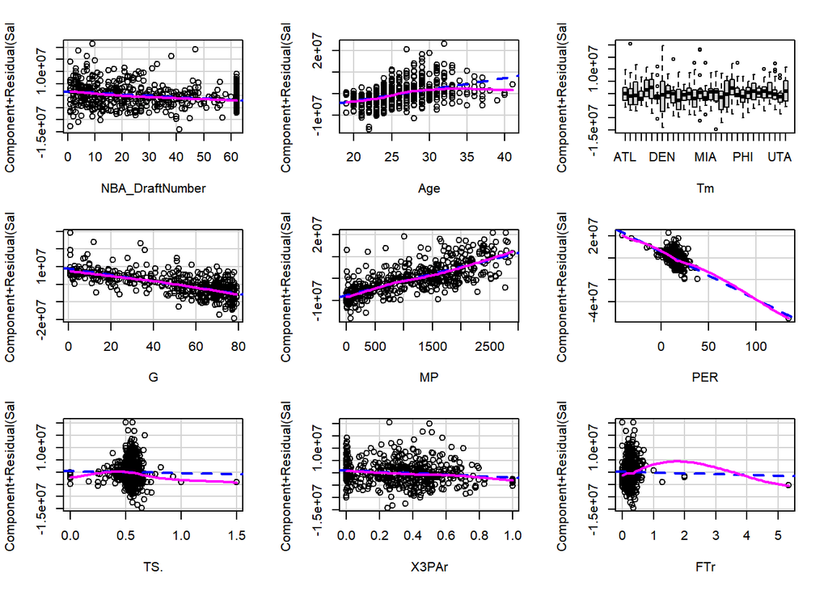

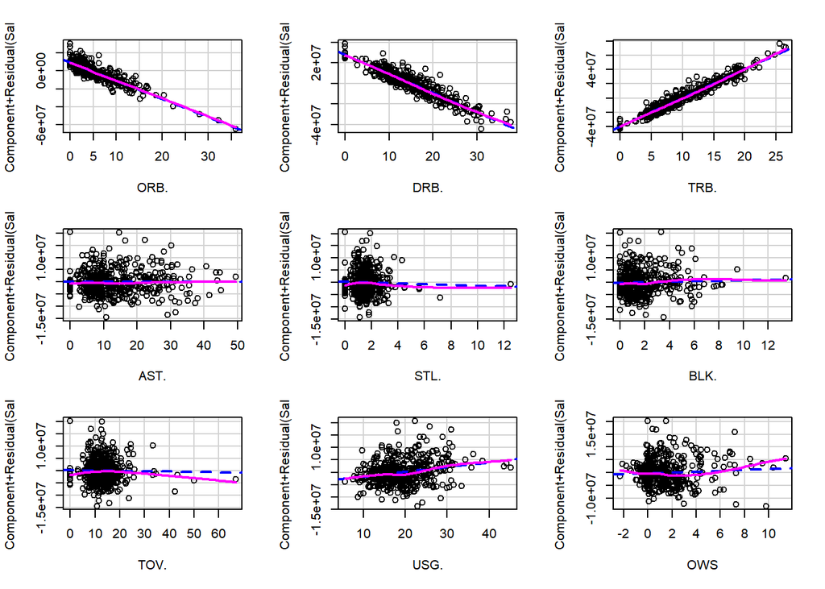

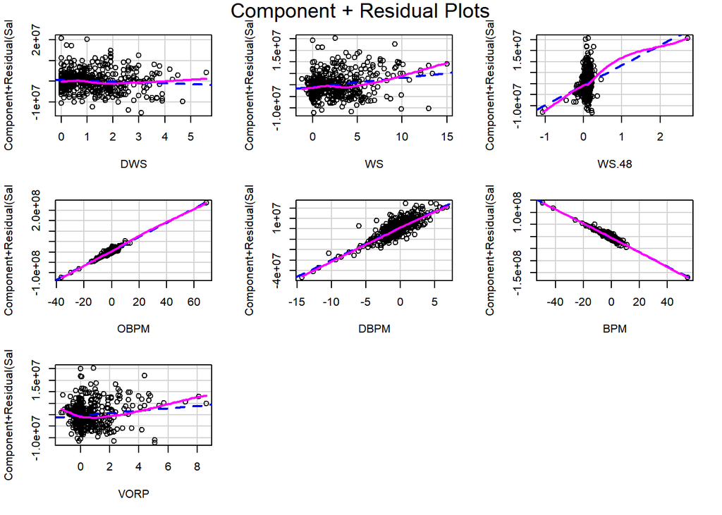

Graficos de residuos parciales: se grafican valores ajustados con respecto a predictores y si no hay problemas de linealidad se obtiene un recta donde se representan los puntos

## Varianza Constante. Homocedasticidad

```
## Non-constant Variance Score Test
## Variance formula: ~ fitted.values
## Chisquare = 80.10689, Df = 1, p = < 2.22e-16
```

El modelo 1 no tiene varianza constante.

## Validación Global

```
##
## Call:
## lm(formula = Salary ~ . - NBA_Country - Player, data = datos)
##
## Residuals:
##       Min        1Q    Median        3Q       Max
## -14498503  -2888765   -458444   2291882  20324440
##
## Coefficients:
##                 Estimate Std. Error t value Pr(>|t|)
## (Intercept)     -3014178    5974976  -0.504    0.614
## NBA_DraftNumber   -58523      13782  -4.246 2.67e-05 ***
## Age               523548      60370   8.672  < 2e-16 ***
## TmBOS            -226264    2172576  -0.104    0.917
## TmBRK             150499    2012351   0.075    0.940
## TmCHI           -1111092    1999593  -0.556    0.579
## TmCHO            1706729    1988558   0.858    0.391
## TmCLE            1371988    2192053   0.626    0.532
## TmDAL           -1048104    1911597  -0.548    0.584
## TmDEN            -932981    2018324  -0.462    0.644
## TmDET             543366    2039128   0.266    0.790
## TmGSW           -1155719    2250042  -0.514    0.608
## TmHOU           -2619580    2152762  -1.217    0.224
## TmIND           -1254149    1933956  -0.648    0.517
## TmLAC            -471968    2042725  -0.231    0.817
## TmLAL           -1311087    1935762  -0.677    0.499
## TmMEM             745313    1919756   0.388    0.698
## TmMIA           -1034150    1985599  -0.521    0.603
## TmMIL            -615601    1984520  -0.310    0.757
## TmMIN            -659045    2162936  -0.305    0.761
## TmNOP           -2255012    2032302  -1.110    0.268
## TmNYK            -315430    1980360  -0.159    0.874
## TmOKC            2214755    2075867   1.067    0.287
## TmORL             538461    1904320   0.283    0.777
## TmPHI           -1842010    2074225  -0.888    0.375
## TmPHO            -747324    1994256  -0.375    0.708
## TmPOR             514615    2020523   0.255    0.799
## TmSAC            -373969    2216251  -0.169    0.866
## TmSAS             187457    2056201   0.091    0.927
## TmTOR            1092707    2089926   0.523    0.601
```

[output cut: 31 more lines]

```
##
##
## ASSESSMENT OF THE LINEAR MODEL ASSUMPTIONS
## USING THE GLOBAL TEST ON 4 DEGREES-OF-FREEDOM:
## Level of Significance =  0.05
##
## Call:
##  gvlma(x = regresion1)
##
##                        Value   p-value                   Decision
## Global Stat        116.08248 0.000e+00 Assumptions NOT satisfied!
## Skewness            32.75183 1.047e-08 Assumptions NOT satisfied!
## Kurtosis            45.60309 1.448e-11 Assumptions NOT satisfied!
## Link Function       37.63793 8.517e-10 Assumptions NOT satisfied!
## Heteroscedasticity   0.08963 7.647e-01    Assumptions acceptable.
```

Si estudiamos la validación global del primero modelo, podemos observar que simplemente cumple la heterocedasticidad.

## Multicolinealidad

```
##                         GVIF Df GVIF^(1/(2*Df))
## NBA_DraftNumber     1.525286  1        1.235025
## Age                 1.199093  1        1.095031
## Tm                 58.305662 30        1.070110
## G                   8.028518  1        2.833464
## MP                 16.448609  1        4.055688
## PER               132.032463  1       11.490538
## TS.                 7.686192  1        2.772398
## X3PAr               9.347340  1        3.057342
## FTr                 1.358397  1        1.165503
## ORB.              859.704362  1       29.320716
## DRB.             1823.430844  1       42.701649
## TRB.             3904.545235  1       62.486360
## AST.                4.043763  1        2.010911
## STL.                4.872328  1        2.207335
## BLK.                8.663124  1        2.943319
## TOV.                2.281199  1        1.510364
## USG.                9.821064  1        3.133858
## OWS              1441.268408  1       37.964041
## DWS               437.508650  1       20.916707
## WS               2915.422706  1       53.994654
## WS.48             109.063018  1       10.443324
## OBPM            11434.107671  1      106.930387
## DBPM             2473.770465  1       49.737013
## BPM             13975.598934  1      118.218437
## VORP               12.140191  1        3.484278
```

```
##                  GVIF    Df GVIF^(1/(2*Df))
## NBA_DraftNumber FALSE FALSE           FALSE
## Age             FALSE FALSE           FALSE
## Tm               TRUE  TRUE           FALSE
## G                TRUE FALSE           FALSE
## MP               TRUE FALSE            TRUE
## PER              TRUE FALSE            TRUE
## TS.              TRUE FALSE           FALSE
## X3PAr            TRUE FALSE           FALSE
## FTr             FALSE FALSE           FALSE
## ORB.             TRUE FALSE            TRUE
## DRB.             TRUE FALSE            TRUE
## TRB.             TRUE FALSE            TRUE
## AST.             TRUE FALSE           FALSE
## STL.             TRUE FALSE           FALSE
## BLK.             TRUE FALSE           FALSE
## TOV.            FALSE FALSE           FALSE
## USG.             TRUE FALSE           FALSE
## OWS              TRUE FALSE            TRUE
## DWS              TRUE FALSE            TRUE
## WS               TRUE FALSE            TRUE
## WS.48            TRUE FALSE            TRUE
## OBPM             TRUE FALSE            TRUE
## DBPM             TRUE FALSE            TRUE
## BPM              TRUE FALSE            TRUE
## VORP             TRUE FALSE           FALSE
```

Si realizamos un estudio de Multicolinealidad, observamos un probelma de multicolinealidad ya que, como regla general, la raiz cuadrada de VIF es mayor que 2.

## Outliers

```
##     rstudent unadjusted p-value Bonferroni p
## 328 4.464562         1.0282e-05     0.004966
## 114 4.205394         3.1773e-05     0.015346
```

Los outliers son los datos que nos son bien predecidos por el modelo. Como son valores positivos, lo que indica que el modelo está subestimando la respuesta.

## Forward Stepwise

```
## Subset selection object
## Call: regsubsets.formula(Salary ~ . - Player - Tm - NBA_Country, datos,
##     method = "forward")
## 24 Variables  (and intercept)
##                 Forced in Forced out
## NBA_DraftNumber     FALSE      FALSE
## Age                 FALSE      FALSE
## G                   FALSE      FALSE
## MP                  FALSE      FALSE
## PER                 FALSE      FALSE
## TS.                 FALSE      FALSE
## X3PAr               FALSE      FALSE
## FTr                 FALSE      FALSE
## ORB.                FALSE      FALSE
## DRB.                FALSE      FALSE
## TRB.                FALSE      FALSE
## AST.                FALSE      FALSE
## STL.                FALSE      FALSE
## BLK.                FALSE      FALSE
## TOV.                FALSE      FALSE
## USG.                FALSE      FALSE
## OWS                 FALSE      FALSE
## DWS                 FALSE      FALSE
## WS                  FALSE      FALSE
## WS.48               FALSE      FALSE
## OBPM                FALSE      FALSE
## DBPM                FALSE      FALSE
## BPM                 FALSE      FALSE
## VORP                FALSE      FALSE
## 1 subsets of each size up to 8
## Selection Algorithm: forward
##          NBA_DraftNumber Age G   MP  PER TS. X3PAr FTr ORB. DRB. TRB. AST. STL.
## 1  ( 1 ) " "             " " " " " " " " " " " "   " " " "  " "  " "  " "  " "
## 2  ( 1 ) " "             "*" " " " " " " " " " "   " " " "  " "  " "  " "  " "
## 3  ( 1 ) "*"             "*" " " " " " " " " " "   " " " "  " "  " "  " "  " "
## 4  ( 1 ) "*"             "*" " " " " " " " " " "   " " " "  " "  " "  " "  " "
## 5  ( 1 ) "*"             "*" "*" " " " " " " " "   " " " "  " "  " "  " "  " "
## 6  ( 1 ) "*"             "*" "*" "*" " " " " " "   " " " "  " "  " "  " "  " "
## 7  ( 1 ) "*"             "*" "*" "*" " " " " " "   " " " "  "*"  " "  " "  " "
## 8  ( 1 ) "*"             "*" "*" "*" " " " " " "   " " " "  "*"  " "  " "  " "
##          BLK. TOV. USG. OWS DWS WS  WS.48 OBPM DBPM BPM VORP
## 1  ( 1 ) " "  " "  " "  " " " " "*" " "   " "  " "  " " " "
## 2  ( 1 ) " "  " "  " "  " " " " "*" " "   " "  " "  " " " "
## 3  ( 1 ) " "  " "  " "  " " " " "*" " "   " "  " "  " " " "
## 4  ( 1 ) " "  " "  "*"  " " " " "*" " "   " "  " "  " " " "
## 5  ( 1 ) " "  " "  "*"  " " " " "*" " "   " "  " "  " " " "
## 6  ( 1 ) " "  " "  "*"  " " " " "*" " "   " "  " "  " " " "
## 7  ( 1 ) " "  " "  "*"  " " " " "*" " "   " "  " "  " " " "
## 8  ( 1 ) " "  " "  "*"  " " " " "*" " "   " "  " "  " " "*"
```

## Backward Stepwise

```
## Start:  AIC=14920.41
## Salary ~ NBA_DraftNumber + Age + G + MP + DRB. + USG. + OWS +
##     VORP
##
##                   Df  Sum of Sq        RSS   AIC
## - USG.             1 4.3937e+13 1.2167e+16 14920
## <none>                          1.2123e+16 14920
## - OWS              1 7.6675e+13 1.2199e+16 14922
## - VORP             1 1.3883e+14 1.2262e+16 14924
## - DRB.             1 1.8049e+14 1.2303e+16 14926
## - NBA_DraftNumber  1 7.8207e+14 1.2905e+16 14949
## - G                1 1.0317e+15 1.3154e+16 14958
## - MP               1 1.3671e+15 1.3490e+16 14970
## - Age              1 2.3191e+15 1.4442e+16 15003
##
## Step:  AIC=14920.15
## Salary ~ NBA_DraftNumber + Age + G + MP + DRB. + OWS + VORP
##
##                   Df  Sum of Sq        RSS   AIC
## <none>                          1.2167e+16 14920
## - OWS              1 8.1867e+13 1.2249e+16 14921
## - VORP             1 1.4576e+14 1.2312e+16 14924
## - DRB.             1 1.7228e+14 1.2339e+16 14925
## - NBA_DraftNumber  1 8.4110e+14 1.3008e+16 14950
## - G                1 1.3310e+15 1.3498e+16 14968
## - MP               1 1.6661e+15 1.3833e+16 14980
## - Age              1 2.2812e+15 1.4448e+16 15001
```

```
##
## Call:
## lm(formula = Salary ~ NBA_DraftNumber + Age + G + MP + DRB. +
##     OWS + VORP, data = datos)
##
## Coefficients:
##     (Intercept)  NBA_DraftNumber              Age                G
##        -6923015           -68459           516255          -151028
##              MP             DRB.              OWS             VORP
##            6045            96138           475868           967741
```

```
## Subset selection object
## Call: regsubsets.formula(Salary ~ . - Player - Tm - NBA_Country, datos,
##     method = "backward")
## 24 Variables  (and intercept)
##                 Forced in Forced out
## NBA_DraftNumber     FALSE      FALSE
## Age                 FALSE      FALSE
## G                   FALSE      FALSE
## MP                  FALSE      FALSE
## PER                 FALSE      FALSE
## TS.                 FALSE      FALSE
## X3PAr               FALSE      FALSE
## FTr                 FALSE      FALSE
## ORB.                FALSE      FALSE
## DRB.                FALSE      FALSE
## TRB.                FALSE      FALSE
## AST.                FALSE      FALSE
## STL.                FALSE      FALSE
## BLK.                FALSE      FALSE
## TOV.                FALSE      FALSE
## USG.                FALSE      FALSE
## OWS                 FALSE      FALSE
## DWS                 FALSE      FALSE
## WS                  FALSE      FALSE
## WS.48               FALSE      FALSE
## OBPM                FALSE      FALSE
## DBPM                FALSE      FALSE
## BPM                 FALSE      FALSE
## VORP                FALSE      FALSE
## 1 subsets of each size up to 8
## Selection Algorithm: backward
##          NBA_DraftNumber Age G   MP  PER TS. X3PAr FTr ORB. DRB. TRB. AST. STL.
## 1  ( 1 ) " "             " " " " "*" " " " " " "   " " " "  " "  " "  " "  " "
## 2  ( 1 ) " "             " " "*" "*" " " " " " "   " " " "  " "  " "  " "  " "
## 3  ( 1 ) " "             "*" "*" "*" " " " " " "   " " " "  " "  " "  " "  " "
## 4  ( 1 ) " "             "*" "*" "*" " " " " " "   " " " "  " "  " "  " "  " "
## 5  ( 1 ) "*"             "*" "*" "*" " " " " " "   " " " "  " "  " "  " "  " "
## 6  ( 1 ) "*"             "*" "*" "*" " " " " " "   " " " "  " "  "*"  " "  " "
## 7  ( 1 ) "*"             "*" "*" "*" " " " " " "   " " "*"  " "  "*"  " "  " "
## 8  ( 1 ) "*"             "*" "*" "*" " " " " " "   " " "*"  " "  "*"  " "  " "
##          BLK. TOV. USG. OWS DWS WS  WS.48 OBPM DBPM BPM VORP
## 1  ( 1 ) " "  " "  " "  " " " " " " " "   " "  " "  " " " "
## 2  ( 1 ) " "  " "  " "  " " " " " " " "   " "  " "  " " " "
## 3  ( 1 ) " "  " "  " "  " " " " " " " "   " "  " "  " " " "
## 4  ( 1 ) " "  " "  " "  " " " " "*" " "   " "  " "  " " " "
## 5  ( 1 ) " "  " "  " "  " " " " "*" " "   " "  " "  " " " "
## 6  ( 1 ) " "  " "  " "  " " " " "*" " "   " "  " "  " " " "
## 7  ( 1 ) " "  " "  " "  " " " " "*" " "   " "  " "  " " " "
## 8  ( 1 ) " "  " "  "*"  " " " " "*" " "   " "  " "  " " " "
```

```
## Start:  AIC=14920.41
## Salary ~ NBA_DraftNumber + Age + G + MP + DRB. + USG. + OWS +
##     VORP
##
##                   Df  Sum of Sq        RSS   AIC
## - USG.             1 4.3937e+13 1.2167e+16 14920
## <none>                          1.2123e+16 14920
## - OWS              1 7.6675e+13 1.2199e+16 14922
## - VORP             1 1.3883e+14 1.2262e+16 14924
## - DRB.             1 1.8049e+14 1.2303e+16 14926
## - NBA_DraftNumber  1 7.8207e+14 1.2905e+16 14949
## - G                1 1.0317e+15 1.3154e+16 14958
## - MP               1 1.3671e+15 1.3490e+16 14970
## - Age              1 2.3191e+15 1.4442e+16 15003
##
## Step:  AIC=14920.15
## Salary ~ NBA_DraftNumber + Age + G + MP + DRB. + OWS + VORP
##
##                   Df  Sum of Sq        RSS   AIC
## <none>                          1.2167e+16 14920
## + USG.             1 4.3937e+13 1.2123e+16 14920
## - OWS              1 8.1867e+13 1.2249e+16 14921
## - VORP             1 1.4576e+14 1.2312e+16 14924
## - DRB.             1 1.7228e+14 1.2339e+16 14925
## - NBA_DraftNumber  1 8.4110e+14 1.3008e+16 14950
## - G                1 1.3310e+15 1.3498e+16 14968
## - MP               1 1.6661e+15 1.3833e+16 14980
## - Age              1 2.2812e+15 1.4448e+16 15001
```

```
##
## Call:
## lm(formula = Salary ~ NBA_DraftNumber + Age + G + MP + DRB. +
##     OWS + VORP, data = datos)
##
## Coefficients:
##     (Intercept)  NBA_DraftNumber              Age                G
##        -6923015           -68459           516255          -151028
##              MP             DRB.              OWS             VORP
##            6045            96138           475868           967741
```

```r
regresion5 = lm(Salary ~ NBA_DraftNumber + Age + G + MP + DRB. + OWS + VORP, data=datos)
summary(regresion5)
```

```
##
## Call:
## lm(formula = Salary ~ NBA_DraftNumber + Age + G + MP + DRB. +
##     OWS + VORP, data = datos)
##
## Residuals:
##       Min        1Q    Median        3Q       Max
## -15682043  -2956754   -376366   2129588  21372375
##
## Coefficients:
##                   Estimate Std. Error t value Pr(>|t|)
## (Intercept)     -6923015.0  1680767.2  -4.119 4.49e-05 ***
## NBA_DraftNumber   -68458.6    11946.6  -5.730 1.78e-08 ***
## Age               516254.9    54704.3   9.437  < 2e-16 ***
## G                -151028.3    20951.1  -7.209 2.24e-12 ***
## MP                  6044.5      749.5   8.065 6.01e-15 ***
## DRB.               96138.5    37069.9   2.593   0.0098 **
## OWS               475868.1   266178.0   1.788   0.0744 .
## VORP              967740.8   405682.8   2.385   0.0174 *
## ---
## Signif. codes:  0 '***' 0.001 '**' 0.01 '*' 0.05 '.' 0.1 ' ' 1
##
## Residual standard error: 5061000 on 475 degrees of freedom
## Multiple R-squared:  0.5388, Adjusted R-squared:  0.532
## F-statistic: 79.28 on 7 and 475 DF,  p-value: < 2.2e-16
```

Obtenemos el modelo de regresion 5 a partir de estudiar los modelos mixtos.

## CONTRASTE DE NORMALIDAD

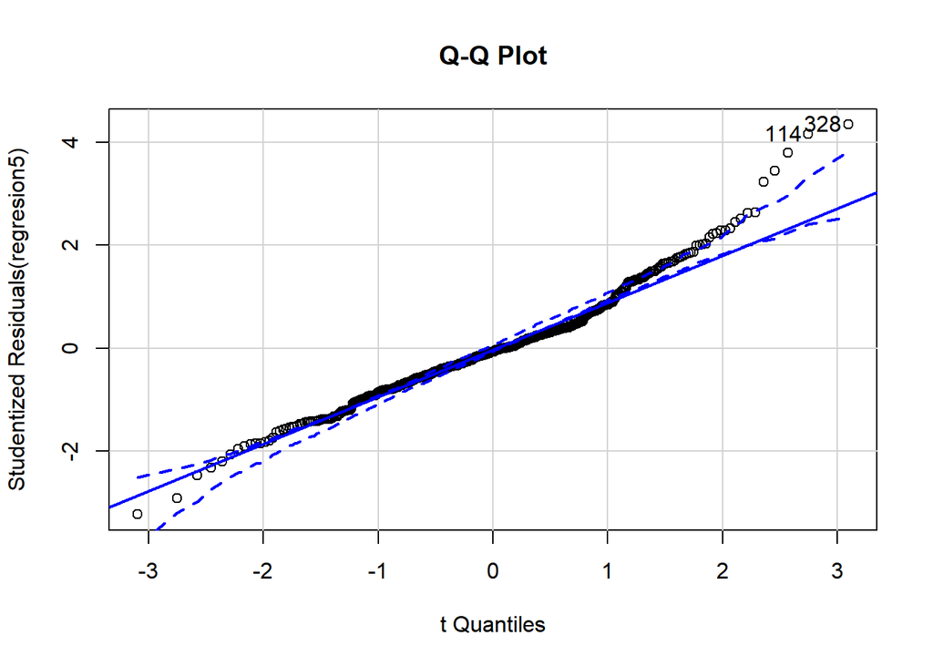

```
## 114 328
## 112 326
```

Si realizamos un contraste de normalidad del modelo de regresion 5, podemos enteder que se parece a una normal

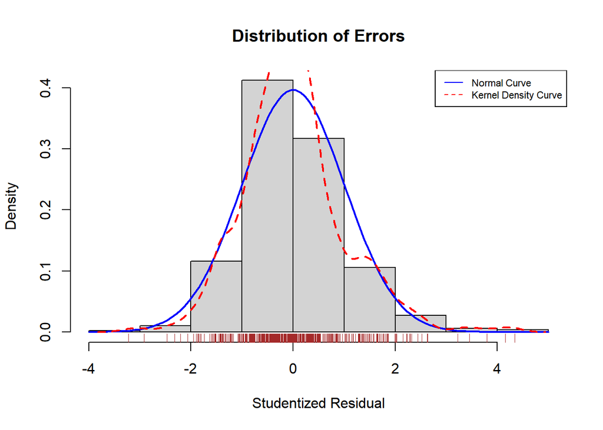

## PREDICCION

```
##      286      338      408      103      113      395      135      424
##  5601366 11678897  5588894  7056920 -1326647  1253403   740077 20449171
##      402      390
## 11728169  1401873
```

Obtenemos el salario de 10 jugadores aleatorios de la NBA.